# KNUST Enrollment Analysis

2016/2017 - 2021/2022

Laurens

June 03, 2025

KNUST Enrollment Summary (2016/2017 - 2021/2022)

| Academic Year | Enrollment Counts Total Enrolled | Enrollment Counts Male Enrolled | Enrollment Counts Female Enrolled | Gender Distribution Male % | Gender Distribution Female % |
| --- | --- | --- | --- | --- | --- |
| 2016/2017 | 15285 | 9541 | 5744 | 62.4% | 37.6% |
| 2017/2018 | 27509 | 13515 | 13995 | 49.1% | 50.9% |
| 2018/2019 | 30980 | 15963 | 15017 | 51.5% | 48.5% |
| 2019/2020 | 35214 | 18195 | 17019 | 51.7% | 48.3% |
| 2020/2021 | 43275 | 22981 | 20294 | 53.1% | 46.9% |
| 2021/2022 | 29420 | 18234 | 11186 | 62.0% | 38.0% |

Year-over-Year Enrollment Growth (2017/2018 - 2021/2022)

| Academic Year | Total Growth | Male Growth | Female Growth |
| --- | --- | --- | --- |
| 2016/2017 | NA% | NA% | NA% |
| 2017/2018 | 80.0% | 41.7% | 143.6% |
| 2018/2019 | 12.6% | 18.1% | 7.3% |
| 2019/2020 | 13.7% | 14.0% | 13.3% |
| 2020/2021 | 22.9% | 26.3% | 19.2% |
| 2021/2022 | -32.0% | -20.7% | -44.9% |

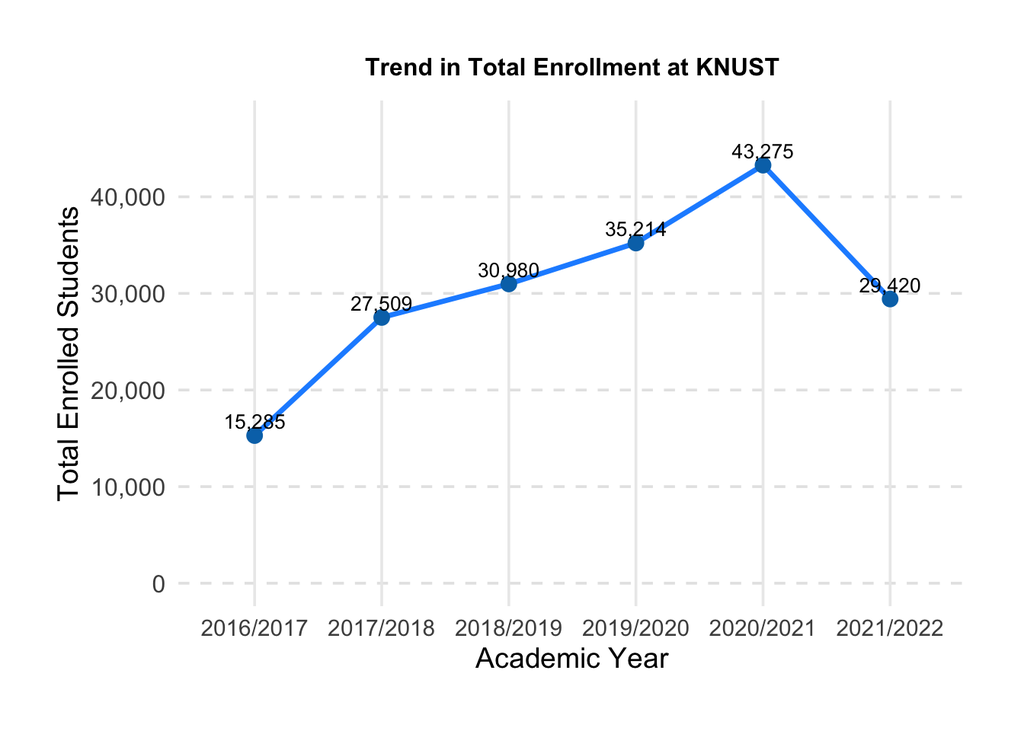

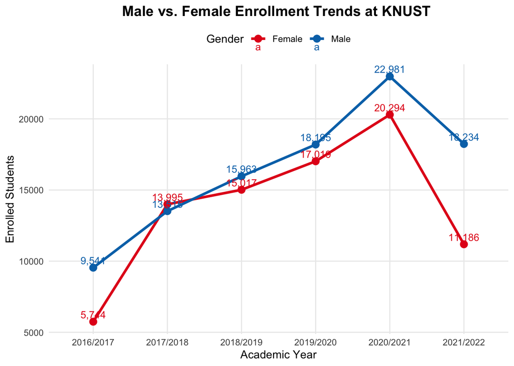

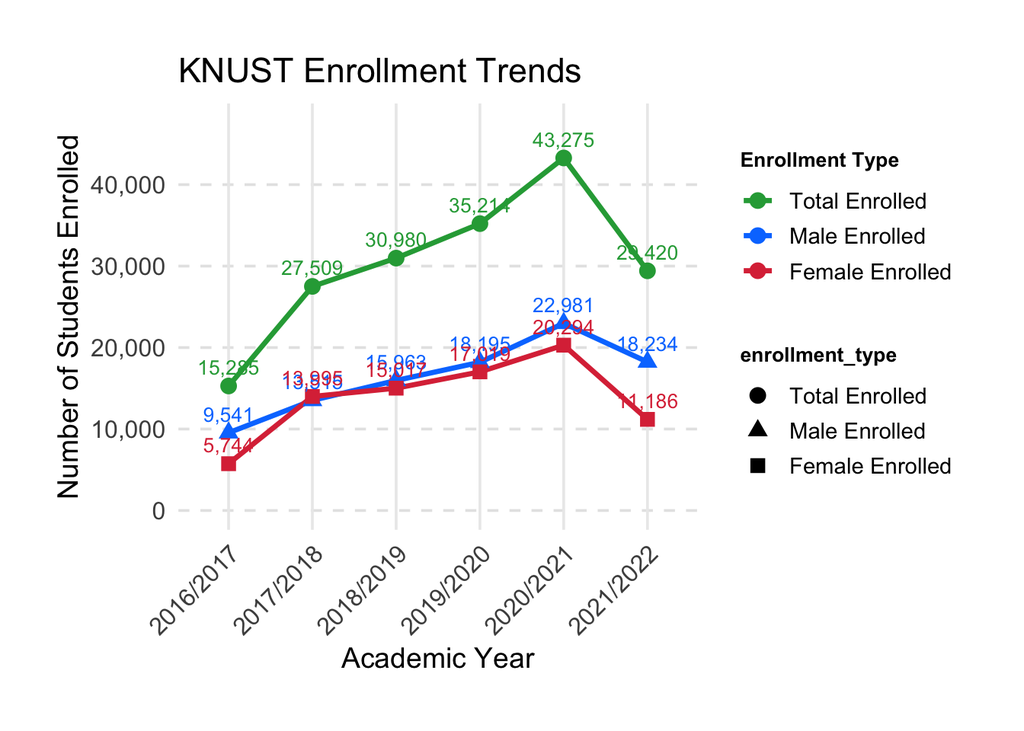

Statistical Summary of KNUST Enrollment (2016/2017 - 2021/2022)

| Avg Total Enrolled | Avg Male % | Avg Female % | Max Total Enrolled | Min Total Enrolled |
| --- | --- | --- | --- | --- |
| 30280.5 | 54.97157 | 45.02903 | 43275 | 15285 |

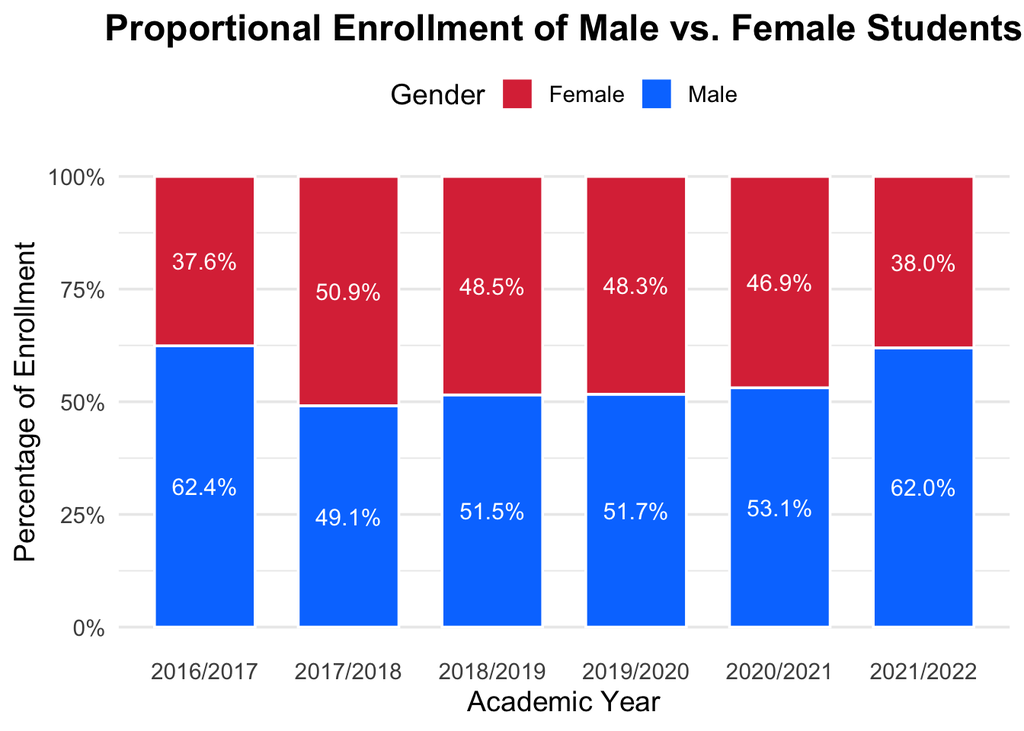

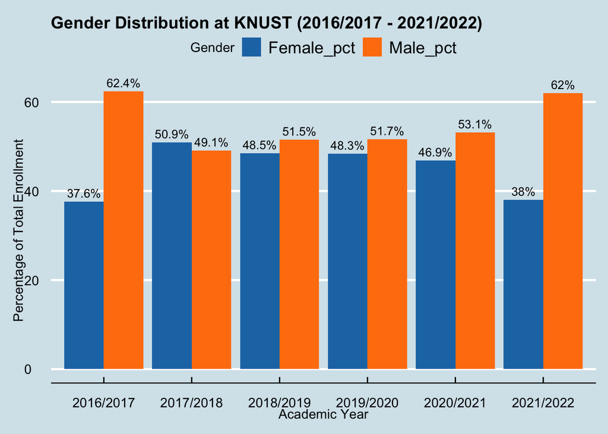

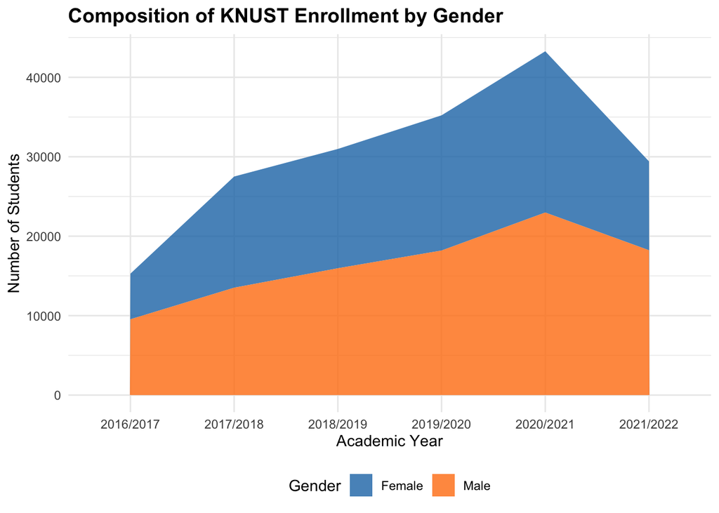

# Observations

Total Enrollment Trends

Overall Growth: Total enrollment increased significantly from 15,285 students in 2016/2017 to a peak of 43,275 in 2020/2021, representing a 183% increase over four years. However, enrollment dropped sharply by 32% to 29,420 in 2021/2022, likely due to limited academic facilities or other external factors.

Year-over-Year Growth: The most significant growth occurred in 2017/2018 (80.0% increase), followed by steady growth until 2020/2021.

Gender Distribution

Enrollment Counts: Male enrollment peaked at 22,981 in 2020/2021, while female enrollment peaked at 20,294 in the same year. Both saw significant declines in 2021/2022 (males: 18,234; females: 11,186).

Gender-Specific Growth

Female Enrollment Growth: Female enrollment saw remarkable growth from 2016/2017 to 2017/2018 (143.6% increase), but experienced the largest decline in 2021/2022 (-44.9%), suggests potential barriers or changes in admission policies.

Male Enrollment Growth: Male enrollment grew steadily, with the highest growth in 2017/2018 (41.7%) and a less severe decline in 2021/2022 (-20.6%) compared to females.

Comparative Analysis: Female enrollment growth was more volatile, with larger swings in growth rates compared to males, indicating potential inconsistencies in female student recruitment or retention.

Total Enrollment Trend: Visualizations (line plots) show a clear upward trend until 2020/2021, followed by a sharp decline, highlighting the need to investigate factors affecting the 2021/2022 drop.

# Summary

Range: Enrollment ranged from 15,285 (2016/2017) to 43,275 (2020/2021).

Implications and Recommendations Investigate 2021/2022 Decline: The significant drop in enrollment, particularly for females (-44.9%), warrants further investigation into potential causes, such as infrastructure limitations, policy changes, or external factors like economic or health-related issues.

Monitor Growth Volatility: The large fluctuations in growth rates ( 80% growth in 2017/2018, -32% in 2021/2022) indicate a need for more stable enrollment strategies to ensure sustainable growth.

# Data source:

QUALITY ASSURANCE & PLANNING OFFICE KWAME NKRUMAH UNIVERSITY OF SCIENCE & TECHNOLOGY

Website: https://qapo.knust.edu.gh/resources/basic-statistics-downloads